# Basic usage

This vignette describes the most basic usage of the `sentopics` package by estimating an LDA model and analysis it’s output. Two other vignettes, describing time series and topic models with sentiment are also available.

# Data

The package is shipped with a sample of press conferences from the European Central bank. For ease of use, the press conferences have been pre-processed into a `tokens` object from the `quanteda` package. (See [quanteda’s introduction](https://quanteda.io/articles/quickstart.html#tokenizing-texts-1) for details on these objects). The press conferences also contains meta-data which can be accessed using `docvars()`.

The press conferences were obtained from [ECB’s website](https://www.ecb.europa.eu/press/press_conference/monetary-policy-statement/html/index.en.html). The package also provides an helper function to replicate the creation of the dataset: `get_ECB_press_conferences()`

```r
library("sentopics")
data("ECB_press_conferences_tokens")
print(ECB_press_conferences_tokens, 3)
# Tokens consisting of 3,860 documents and 5 docvars.
# 1_1 :
#  [1] "outcome"           "meeting"           "decision"
#  [4] ""                  "ecb"               "general"
#  [7] "council"           "governing_council" "executive"
# [10] "board"             "accordance"        "escb"
# [ ... and 7 more ]
#
# 1_2 :
#  [1] ""              "state"         "government"    "member"
#  [5] "executive"     "board"         "ecb"           "president"
#  [9] "vice"          "president"     "date"          "establishment"
# [ ... and 13 more ]
#
# 1_3 :
#  [1] ""          "meeting"   "executive" "board"     "meeting"   ""
#  [7] "general"   ""          "meeting"   ""
#
# [ reached max_ndoc ... 3,857 more documents ]
head(docvars(ECB_press_conferences_tokens))
#        .date doc_id                                        title
# 1 1998-06-09      1 ECB Press conference: Introductory statement
# 2 1998-06-09      1 ECB Press conference: Introductory statement
# 3 1998-06-09      1 ECB Press conference: Introductory statement
# 4 1998-06-09      1 ECB Press conference: Introductory statement
# 5 1998-06-09      1 ECB Press conference: Introductory statement
# 6 1998-06-09      1 ECB Press conference: Introductory statement
#                                                               section_title
# 1 Willem F. Duisenberg, President of the European Central Bank, 9 June 1998
# 2 Willem F. Duisenberg, President of the European Central Bank, 9 June 1998
# 3 Willem F. Duisenberg, President of the European Central Bank, 9 June 1998
# 4 Willem F. Duisenberg, President of the European Central Bank, 9 June 1998
# 5 Willem F. Duisenberg, President of the European Central Bank, 9 June 1998
# 6 Willem F. Duisenberg, President of the European Central Bank, 9 June 1998
#    .sentiment
# 1 -0.01470588
# 2 -0.02500000
# 3  0.00000000
# 4  0.00000000
# 5  0.00000000
# 6  0.00000000
```

# Topic modeling

## Introduction

`sentopics` implements three types of topic model. The simplest, Latent Dirichlet Allocation (LDA), assumes that textual documents are issued from a generative process involving $K$ topics.

A given document $d$ is constituted of a list of words $d = (w_1, \dots, w_N)$, with $N$ being the document’s length. Each word $w_i$ originates from a vocabulary consisting of $V$ distinct terms. Then, documents are generated from the following random process:

1. For each topic $k \in K$, a distribution $\phi_k$ over the vocabulary is drawn. This distribution represent the probability of a word appearing given it belong to the topic and is drawn from a Dirichlet distribution with hyperparameter $\beta$.
   $$\phi
   \sim Dirichlet(\beta)$$
2. For each document, a mixture of the $K$ topics, $\theta_d$, assign the probability of a word in document $d$ being generated from topic $k$. This mixture is also drawn from a Dirichlet distribution with hyperparameter $\alpha$.
   $$\theta \sim Dirichlet(\alpha)$$
3. For each word position $i$ of document $d$, the following sequence of draws is executed:
   1. A latent topic assignment $z_i$ is drawn from the document mixture. $z_i \sim Multinomial(\theta)$
   2. A word $w_i$ is drawn from the topic’s vocabulary distribution. $w_i \sim Multinomial(\phi_{z_i})$

In `sentopics` the LDA model is estimated through Gibbs sampling, that iteratively sample the topic assignment $z_i$ of every word of the corpus until reaching a convergence. The topic assignments are sampled from the following distribution:
$$p(z_i =
k|w,z^{-i}) \propto
\frac{n_{k,v,.}^{-i} + \beta}{n_{k,.,.}^{-i} + V\beta}
\frac{n_{k,.,d}^{-i} + \alpha}{n_{.,.,d}^{-i} + K\alpha},$$
where $n_{k,v,d}$ is the count of words at index $v$ of the vocabulary, assigned to topic $k$ and part of document $d$. The replacement of one of the indices $\{k,v,d\}$ by a dot indicates instead the count for all topics, all vocabulary indices or all documents. The superscript $-i$ indicates that the current word position $i$ is left out from the count variables.

## Estimating LDA models with `sentopics`

The estimation of an LDA model is easily replicated using the `LDA()` and `fit()` function. The first function prepares the `R` object and initialize the assignment of the latent topics. The second function estimates the model using Gibbs sampling for a given number of iterations. Note that `fit()` may be used to iterate the model multiple times without resetting the estimation.

```r
set.seed(123)
lda <- LDA(ECB_press_conferences_tokens)
lda
# An LDA model with 5 topics. Currently fitted by 0 Gibbs sampling iterations.
# ------------------Useful methods------------------
# fit       :Estimate the model using Gibbs sampling
# topics    :Return the most important topic of each document
# topWords  :Return a data.table with the top words of each topic/sentiment
# plot      :Plot a sunburst chart representing the estimated mixtures
# This message is displayed once per session, unless calling `print(x, extended = TRUE)`
lda <- fit(lda, iterations = 100)
lda
# An LDA model with 5 topics. Currently fitted by 100 Gibbs sampling iterations.
```

Internally, the `lda` object is stored as a list and contains the model’s parameters and outputs.

```r
str(lda, max.level = 1, give.attr = FALSE)
# List of 10
#  $ tokens       :List of 3860
#  $ vocabulary   :Classes 'data.table' and 'data.frame':   1168 obs. of  3 variables:
#  $ K            : num 5
#  $ alpha        : num [1:5, 1] 1 1 1 1 1
#  $ beta         : num [1:5, 1:1168] 0.01 0.01 0.01 0.01 0.01 0.01 0.01 0.01 0.01 0.01 ...
#  $ it           : num 100
#  $ za           :List of 3860
#  $ theta        : num [1:3860, 1:5] 0.0455 0.0357 0.0909 0.0667 0.0625 ...
#  $ phi          : num [1:1168, 1:5] 4.32e-07 4.32e-07 4.32e-07 6.47e-03 4.32e-07 ...
#  $ logLikelihood: num [1:100, 1] -943778 -927554 -912671 -893733 -864875 ...
```

`tokens` is the initial tokens object used to create the model. `vocabulary` is a data.frame indexing the set of words. `K` is the number of topics. `alpha` is the hyperparameter of the document-topic mixtures. `beta` is the hyperparameter of the topic-word mixtures. `it` is the number of iterations of the model. `za` contains the topic assignments of each word of the corpus. `theta` are the estimated document-topic mixtures. `phi` are the estimated topic-word mixtures. `logLikelihood` is the log-likelihood of the model at each iteration.

Estimated mixtures are easily accessible through the `$` operator. But the package also includes the `topWords()` function to extract the most probable words of each topic. `topWords()` includes three types of outputs: *long* `data.table`/`data-frame`, `matrix` or `ggplot` object (also accessible through the alias `plot_topWords()`).

```r
head(lda$theta)
#       topic
# doc_id     topic1     topic2    topic3     topic4     topic5
#    1_1 0.04545455 0.04545455 0.7727273 0.04545455 0.09090909
#    1_2 0.03571429 0.14285714 0.7500000 0.03571429 0.03571429
#    1_3 0.09090909 0.09090909 0.6363636 0.09090909 0.09090909
#    1_4 0.06666667 0.06666667 0.7333333 0.06666667 0.06666667
#    1_5 0.06250000 0.06250000 0.7500000 0.06250000 0.06250000
#    1_6 0.05263158 0.10526316 0.5789474 0.10526316 0.15789474
topWords(lda, output = "matrix")
#       topic1           topic2       topic3              topic4
#  [1,] "price"          "fiscal"     "governing_council" "growth"
#  [2,] "inflation"      "euro_area"  "ecb"               "quarter"
#  [3,] "development"    "growth"     "meeting"           "loan"
#  [4,] "annual"         "country"    "president"         "financial"
#  [5,] "increase"       "policy"     "bank"              "euro_area"
#  [6,] "projection"     "reform"     "operation"         "rate"
#  [7,] "hicp"           "structural" "outcome"           "sector"
#  [8,] "oil"            "market"     "press"             "condition"
#  [9,] "euro_area"      "economic"   "vice"              "annual"
# [10,] "inflation_rate" "measure"    "euro"              "credit"
#       topic5
#  [1,] "risk"
#  [2,] "economic"
#  [3,] "monetary"
#  [4,] "price_stability"
#  [5,] "euro_area"
#  [6,] "development"
#  [7,] "interest_rate"
#  [8,] "outlook"
#  [9,] "monetary_policy"
# [10,] "growth"
```

In addition, document-level is facilitated through the use of the `melt()` method, that joins estimated topical proportions to document metadata present in the `tokens` input. This result in a *long* `data.table`/`data.frame` that can be used for plotting or easily reshaped to a wide format (for example using `data.table::dcast`).

```r
melt(lda, include_docvars = TRUE)
#         topic       prob      .date    .id doc_id
#        <fctr>      <num>     <Date> <char> <char>
#     1: topic1 0.04545455 1998-06-09    1_1      1
#     2: topic1 0.03571429 1998-06-09    1_2      1
#     3: topic1 0.09090909 1998-06-09    1_3      1
#     4: topic1 0.06666667 1998-06-09    1_4      1
#     5: topic1 0.06250000 1998-06-09    1_5      1
#    ---
# 19296: topic5 0.28947368 2021-12-16 260_20    260
# 19297: topic5 0.10526316 2021-12-16 260_21    260
# 19298: topic5 0.05000000 2021-12-16 260_22    260
# 19299: topic5 0.41025641 2021-12-16 260_23    260
# 19300: topic5 0.14285714 2021-12-16 260_24    260
#                                               title
#                                              <char>
#     1: ECB Press conference: Introductory statement
#     2: ECB Press conference: Introductory statement
#     3: ECB Press conference: Introductory statement
#     4: ECB Press conference: Introductory statement
#     5: ECB Press conference: Introductory statement
#    ---
# 19296:                             PRESS CONFERENCE
# 19297:                             PRESS CONFERENCE
# 19298:                             PRESS CONFERENCE
# 19299:                             PRESS CONFERENCE
# 19300:                             PRESS CONFERENCE
#                                                                             section_title
#                                                                                    <char>
#     1:          Willem F. Duisenberg, President of the European Central Bank, 9 June 1998
#     2:          Willem F. Duisenberg, President of the European Central Bank, 9 June 1998
#     3:          Willem F. Duisenberg, President of the European Central Bank, 9 June 1998
#     4:          Willem F. Duisenberg, President of the European Central Bank, 9 June 1998
#     5:          Willem F. Duisenberg, President of the European Central Bank, 9 June 1998
#    ---
# 19296: Christine Lagarde, President of the ECB,Luis de Guindos, Vice-President of the ECB
# 19297: Christine Lagarde, President of the ECB,Luis de Guindos, Vice-President of the ECB
# 19298: Christine Lagarde, President of the ECB,Luis de Guindos, Vice-President of the ECB
# 19299: Christine Lagarde, President of the ECB,Luis de Guindos, Vice-President of the ECB
# 19300: Christine Lagarde, President of the ECB,Luis de Guindos, Vice-President of the ECB
#         .sentiment
#              <num>
#     1: -0.01470588
#     2: -0.02500000
#     3:  0.00000000
#     4:  0.00000000
#     5:  0.00000000
#    ---
# 19296: -0.01960784
# 19297:  0.00000000
# 19298:  0.05555556
# 19299: -0.01052632
# 19300:  0.00000000
```

To ease the result analysis, we can rename the default topic labels using the `sentopics_labels()` function. As a result, all outputs of the model will now display the custom labels.

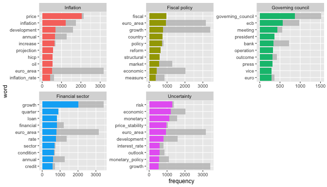

```r
sentopics_labels(lda) <- list(
  topic = c("Inflation", "Fiscal policy", "Governing council", "Financial sector", "Uncertainty")
)
head(lda$theta)
#       topic
# doc_id  Inflation Fiscal policy Governing council Financial sector Uncertainty
#    1_1 0.04545455    0.04545455         0.7727273       0.04545455  0.09090909
#    1_2 0.03571429    0.14285714         0.7500000       0.03571429  0.03571429
#    1_3 0.09090909    0.09090909         0.6363636       0.09090909  0.09090909
#    1_4 0.06666667    0.06666667         0.7333333       0.06666667  0.06666667
#    1_5 0.06250000    0.06250000         0.7500000       0.06250000  0.06250000
#    1_6 0.05263158    0.10526316         0.5789474       0.10526316  0.15789474
plot_topWords(lda) + ggplot2::theme_grey(base_size = 9)
```

Besides modifying topic labels, it is also possible to merge topics into a greater thematic. This is often useful when estimating a large number of topics (e.g, K > 15). The `mergeTopics()` does this job and re-label topics accordingly.

```r
merged <- mergeTopics(lda, list(
  `Big big thematic` = c(1, 3:5),
  `Fical policy` = 2
))
merged
# An LDA model with 2 topics. Currently fitted by 100 Gibbs sampling iterations.
```

Note that merging topics is only useful for presentation purpose. Using again `fit` on a model with merged topics will drastically change the results as the current state of the model does not results from a standard estimation with the merged set of parameters.

```r
plot(lda)
```

[output not shown]